# Временные ряды: прогноз посетителей бизнес-центра

```python
from __future__ import annotations

import warnings
from dataclasses import dataclass
from pathlib import Path

import matplotlib.pyplot as plt
import numpy as np
import pandas as pd
import seaborn as sns
from IPython.display import Markdown, display
from sklearn.ensemble import HistGradientBoostingRegressor, RandomForestClassifier
from sklearn.metrics import (
    accuracy_score,
    average_precision_score,
    f1_score,
    mean_absolute_error,
    mean_squared_error,
    precision_score,
    r2_score,
    recall_score,
    roc_auc_score,
)
from statsmodels.tsa.holtwinters import ExponentialSmoothing

warnings.filterwarnings("ignore")
sns.set_theme(style="whitegrid", context="notebook")
pd.set_option("display.max_columns", 120)
pd.set_option("display.float_format", lambda x: f"{x:,.4f}")

RANDOM_STATE = 42
DATA_DIR = Path(".")
```

```python
def smape(y_true, y_pred, eps=1e-9):
    y_true = np.asarray(y_true, dtype=float)
    y_pred = np.asarray(y_pred, dtype=float)
    return 100 * np.mean(2 * np.abs(y_true - y_pred) / (np.abs(y_true) + np.abs(y_pred) + eps))


def regression_metrics(y_true, y_pred):
    y_true = np.asarray(y_true, dtype=float)
    y_pred = np.asarray(y_pred, dtype=float)
    return {
        "MAE": mean_absolute_error(y_true, y_pred),
        "RMSE": mean_squared_error(y_true, y_pred) ** 0.5,
        "SMAPE_%": smape(y_true, y_pred),
        "Bias": np.mean(y_true - y_pred),
        "R2": r2_score(y_true, y_pred),
    }


def classification_metrics(y_true, y_prob, threshold=0.3):
    y_pred = (np.asarray(y_prob) >= threshold).astype(int)
    return {
        "threshold": threshold,
        "accuracy": accuracy_score(y_true, y_pred),
        "precision": precision_score(y_true, y_pred, zero_division=0),
        "recall": recall_score(y_true, y_pred, zero_division=0),
        "f1": f1_score(y_true, y_pred, zero_division=0),
        "roc_auc": roc_auc_score(y_true, y_prob),
        "pr_auc": average_precision_score(y_true, y_prob),
    }
```

## Класс решения

Класс ниже хранит основную логику задания:

- `mark_events` размечает интервалы мероприятий;
- `preprocess` строит календарные, сезонные и event-признаки;
- `add_lag_features` строит лаги на исторических данных;
- `fit_regressor` и `predict_counts_recursive` обучают и применяют прогнозную модель без утечки test-таргета в лаги;
- `fit_event_classifier` и `predict_event_probability` обучают классификатор события.

```python
@dataclass
class MallTrafficTimeSeries:
    freq_minutes: int = 30
    lags: tuple[int, ...] = (1, 2, 48, 96, 336)
    fourier_order: int = 3
    event_interval_closed: bool = True

    def __post_init__(self):
        self.freq = pd.Timedelta(minutes=self.freq_minutes)
        self.regressor = HistGradientBoostingRegressor(
            loss="poisson",
            max_iter=400,
            learning_rate=0.035,
            max_leaf_nodes=31,
            l2_regularization=0.05,
            random_state=RANDOM_STATE,
        )
        self.classifier = RandomForestClassifier(
            n_estimators=300,
            max_depth=8,
            min_samples_leaf=5,
            class_weight="balanced",
            random_state=RANDOM_STATE,
            n_jobs=-1,
        )

    def fit_time_origin(self, counters: pd.DataFrame):
        self.time_origin_ = pd.to_datetime(counters["dt"]).min()
        return self

    def mark_events(self, counters: pd.DataFrame, events: pd.DataFrame) -> pd.DataFrame:
        df = counters.copy()
        df["dt"] = pd.to_datetime(df["dt"])
        df = df.sort_values("dt").reset_index(drop=True)

        df["is_event"] = 0
        df["event_duration_min"] = 0.0
        df["minutes_since_event_start"] = 0.0
        df["minutes_to_event_end"] = 0.0
        df["event_progress"] = 0.0

        events = events.copy()
        if not events.empty:
            events["dt_start"] = pd.to_datetime(events["dt_start"])
            events["dt_end"] = pd.to_datetime(events["dt_end"])

        for _, event in events.iterrows():
            if self.event_interval_closed:
                mask = (df["dt"] >= event["dt_start"]) & (df["dt"] <= event["dt_end"])
            else:
                mask = (df["dt"] >= event["dt_start"]) & (df["dt"] < event["dt_end"])

            duration = max((event["dt_end"] - event["dt_start"]).total_seconds() / 60, self.freq_minutes)
            df.loc[mask, "is_event"] = 1
            df.loc[mask, "event_duration_min"] = duration
            df.loc[mask, "minutes_since_event_start"] = (
                df.loc[mask, "dt"] - event["dt_start"]
            ).dt.total_seconds() / 60
            df.loc[mask, "minutes_to_event_end"] = (
                event["dt_end"] - df.loc[mask, "dt"]
            ).dt.total_seconds() / 60
            df.loc[mask, "event_progress"] = df.loc[mask, "minutes_since_event_start"] / duration

        return df

    def preprocess(self, counters: pd.DataFrame, events: pd.DataFrame) -> pd.DataFrame:
        if not hasattr(self, "time_origin_"):
            self.fit_time_origin(counters)

        df = self.mark_events(counters, events)
        dt = df["dt"]
        df["t_idx"] = ((dt - self.time_origin_).dt.total_seconds() / (60 * self.freq_minutes)).astype(int)
        df["slot"] = dt.dt.hour * 2 + (dt.dt.minute // 30)
        df["dow"] = dt.dt.dayofweek
        df["day"] = dt.dt.day
        df["week"] = dt.dt.isocalendar().week.astype(int)
        df["is_weekend"] = (df["dow"] >= 5).astype(int)
        df["is_night"] = ((dt.dt.hour < 8) | (dt.dt.hour >= 22)).astype(int)
        df["is_working_hours"] = ((dt.dt.hour >= 9) & (dt.dt.hour <= 19) & (df["dow"] < 5)).astype(int)

        for k in range(1, self.fourier_order + 1):
            df[f"day_sin_{k}"] = np.sin(2 * np.pi * k * df["slot"] / 48)
            df[f"day_cos_{k}"] = np.cos(2 * np.pi * k * df["slot"] / 48)

        week_position = df["dow"] * 48 + df["slot"]
        for k in range(1, self.fourier_order + 1):
            df[f"week_sin_{k}"] = np.sin(2 * np.pi * k * week_position / 336)
            df[f"week_cos_{k}"] = np.cos(2 * np.pi * k * week_position / 336)

        return df

    def add_lag_features(self, df: pd.DataFrame) -> pd.DataFrame:
        df = df.sort_values("dt").reset_index(drop=True).copy()
        for lag in self.lags:
            df[f"lag_{lag}"] = df["cnt"].shift(lag)
            min_periods = 1 if lag == 1 else min(lag, 10)
            df[f"roll_mean_{lag}"] = df["cnt"].shift(1).rolling(lag, min_periods=min_periods).mean()
        return df

    def make_supervised_frame(self, counters: pd.DataFrame, events: pd.DataFrame) -> pd.DataFrame:
        return self.add_lag_features(self.preprocess(counters, events))

    def _feature_columns(self, df: pd.DataFrame, include_event_schedule: bool = True):
        drop_cols = {"dt", "cnt"}
        if not include_event_schedule:
            drop_cols |= {
                "is_event",
                "event_duration_min",
                "minutes_since_event_start",
                "minutes_to_event_end",
                "event_progress",
            }
        return [col for col in df.columns if col not in drop_cols]

    def fit_regressor(self, counters: pd.DataFrame, events: pd.DataFrame):
        train = self.make_supervised_frame(counters, events).dropna().copy()
        self.regression_features_ = self._feature_columns(train, include_event_schedule=True)
        self.lag_fill_values_ = train[self.regression_features_].median(numeric_only=True)
        self.regressor.fit(train[self.regression_features_], train["cnt"])
        self.train_history_ = train[["dt", "cnt"]].copy()
        return self

    def _add_recursive_lags_to_row(self, row: pd.Series, history: pd.Series) -> pd.Series:
        row = row.copy()
        current_dt = row["dt"]
        for lag in self.lags:
            lag_dt = current_dt - lag * self.freq
            row[f"lag_{lag}"] = history.get(lag_dt, np.nan)
            previous_values = history[history.index < current_dt].tail(lag)
            min_periods = 1 if lag == 1 else min(lag, 10)
            row[f"roll_mean_{lag}"] = previous_values.mean() if len(previous_values) >= min_periods else history.mean()
        return row

    def predict_counts_recursive(self, future_counters: pd.DataFrame, future_events: pd.DataFrame):
        future_base = self.preprocess(future_counters, future_events)
        history = self.train_history_.set_index("dt")["cnt"].copy()
        predictions = []
        rows = []

        for _, row in future_base.iterrows():
            row_with_lags = self._add_recursive_lags_to_row(row, history)
            X = pd.DataFrame([row_with_lags[self.regression_features_].to_dict()])
            X = X.fillna(self.lag_fill_values_)
            pred = float(self.regressor.predict(X)[0])
            pred = max(0.0, pred)
            predictions.append(pred)
            rows.append(row_with_lags)
            history.loc[row_with_lags["dt"]] = pred

        result = pd.DataFrame(rows)
        result["cnt_pred"] = predictions
        return result

    def fit_event_classifier(self, counters: pd.DataFrame, events: pd.DataFrame):
        train = self.make_supervised_frame(counters, events).dropna().copy()
        self.classification_features_ = self._feature_columns(train, include_event_schedule=False)
        self.classification_fill_values_ = train[self.classification_features_].median(numeric_only=True)
        self.classifier.fit(train[self.classification_features_], train["is_event"])
        return self

    def predict_event_probability(self, counters: pd.DataFrame, events: pd.DataFrame):
        df = self.make_supervised_frame(counters, events)
        X = df[self.classification_features_].fillna(self.classification_fill_values_)
        return self.classifier.predict_proba(X)[:, 1]
```

## Загрузка данных

```python
counters_train = pd.read_csv(DATA_DIR / "counters_train.csv", parse_dates=["dt"])
counters_test = pd.read_csv(DATA_DIR / "counters_test.csv", parse_dates=["dt"])
events_train = pd.read_csv(DATA_DIR / "events_train.csv", parse_dates=["dt_start", "dt_end"])
events_test = pd.read_csv(DATA_DIR / "events_test.csv", parse_dates=["dt_start", "dt_end"])

display(counters_train.head())
display(events_train.head())

print("counters_train:", counters_train.shape, counters_train["dt"].min(), counters_train["dt"].max())
print("counters_test :", counters_test.shape, counters_test["dt"].min(), counters_test["dt"].max())
print("events_train  :", events_train.shape)
print("events_test   :", events_test.shape)
```

|  | dt | cnt |
| --- | --- | --- |
| 0 | 2005-07-24 00:00:00 | 0 |
| 1 | 2005-07-24 00:30:00 | 0 |
| 2 | 2005-07-24 01:00:00 | 0 |
| 3 | 2005-07-24 01:30:00 | 0 |
| 4 | 2005-07-24 02:00:00 | 0 |

|  | dt_start | dt_end | event_type |
| --- | --- | --- | --- |
| 0 | 2005-07-26 11:00:00 | 2005-07-26 14:00:00 | event |
| 1 | 2005-07-29 08:00:00 | 2005-07-29 11:00:00 | event |
| 2 | 2005-08-02 15:30:00 | 2005-08-02 16:30:00 | event |
| 3 | 2005-08-04 16:30:00 | 2005-08-04 17:30:00 | event |
| 4 | 2005-08-05 08:00:00 | 2005-08-05 11:00:00 | event |

```
counters_train: (3552, 2) 2005-07-24 00:00:00 2005-10-05 23:30:00
counters_test : (1488, 2) 2005-10-06 00:00:00 2005-11-05 23:30:00
events_train  : (22, 3)
events_test   : (8, 3)
```

```python
def time_gaps_report(df, name):
    gaps = df["dt"].sort_values().diff().dropna()
    print(name)
    print("  unique gaps:", gaps.value_counts().head().to_dict())
    print("  missing cnt:", df["cnt"].isna().sum())
    print("  duplicated dt:", df["dt"].duplicated().sum())


time_gaps_report(counters_train, "train")
time_gaps_report(counters_test, "test")

display(pd.concat([
    counters_train["cnt"].describe().rename("train_cnt"),
    counters_test["cnt"].describe().rename("test_cnt"),
], axis=1))
```

```
train
  unique gaps: {Timedelta('0 days 00:30:00'): 3551}
  missing cnt: 0
  duplicated dt: 0
test
  unique gaps: {Timedelta('0 days 00:30:00'): 1487}
  missing cnt: 0
  duplicated dt: 0
```

|  | train_cnt | test_cnt |
| --- | --- | --- |
| count | 3,552.0000 | 1,488.0000 |
| mean | 7.0265 | 21.0565 |
| std | 14.1774 | 33.5435 |
| min | 0.0000 | 0.0000 |
| 25% | 0.0000 | 0.0000 |
| 50% | 1.0000 | 5.0000 |
| 75% | 7.0000 | 32.0000 |
| max | 197.0000 | 288.0000 |

Вывод из проверки регулярности: ряд идет строго с шагом 30 минут, пропусков и дублей по времени нет. Test заметно отличается по уровню от train, поэтому одной сезонности недостаточно: нужен тренд/динамика и отдельный учет мероприятий.

## Разметка событий и EDA

```python
ts_model = MallTrafficTimeSeries()
ts_model.fit_time_origin(counters_train)

train_marked = ts_model.preprocess(counters_train, events_train)
test_marked = ts_model.preprocess(counters_test, events_test)

event_summary = pd.DataFrame({
    "part": ["train", "test"],
    "rows": [len(train_marked), len(test_marked)],
    "event_rows": [int(train_marked["is_event"].sum()), int(test_marked["is_event"].sum())],
    "event_share": [train_marked["is_event"].mean(), test_marked["is_event"].mean()],
    "events_count": [len(events_train), len(events_test)],
})
display(event_summary)

display(train_marked.groupby("is_event")["cnt"].describe())
display(test_marked.groupby("is_event")["cnt"].describe())
```

|  | part | rows | event_rows | event_share | events_count |
| --- | --- | --- | --- | --- | --- |
| 0 | train | 3552 | 160 | 0.0450 | 22 |
| 1 | test | 1488 | 46 | 0.0309 | 8 |

| is_event | count | mean | std | min | 25% | 50% | 75% | max |
| --- | --- | --- | --- | --- | --- | --- | --- | --- |
| 0 | 3,392.0000 | 6.2703 | 12.4408 | 0.0000 | 0.0000 | 0.0000 | 6.0000 | 125.0000 |
| 1 | 160.0000 | 23.0562 | 30.2882 | 0.0000 | 5.0000 | 12.5000 | 29.2500 | 197.0000 |

| is_event | count | mean | std | min | 25% | 50% | 75% | max |
| --- | --- | --- | --- | --- | --- | --- | --- | --- |
| 0 | 1,442.0000 | 19.7677 | 32.4389 | 0.0000 | 0.0000 | 5.0000 | 28.0000 | 288.0000 |
| 1 | 46.0000 | 61.4565 | 41.9829 | 0.0000 | 29.7500 | 59.0000 | 87.7500 | 211.0000 |

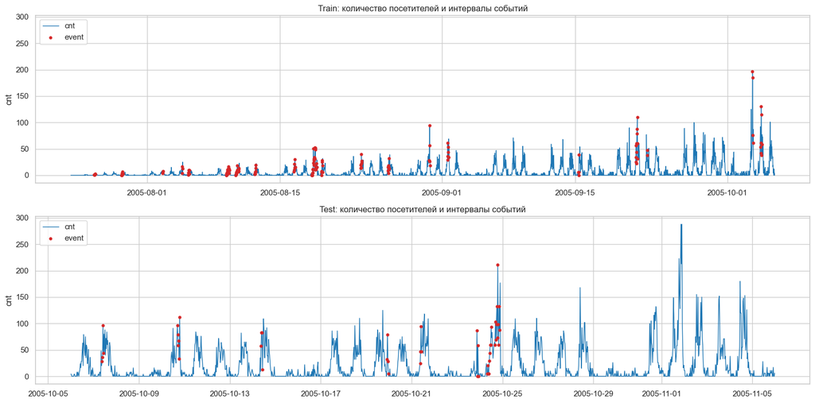

```python
fig, axes = plt.subplots(2, 1, figsize=(16, 8), sharey=True)

for ax, data, title in [
    (axes[0], train_marked, "Train: количество посетителей и интервалы событий"),
    (axes[1], test_marked, "Test: количество посетителей и интервалы событий"),
]:
    ax.plot(data["dt"], data["cnt"], lw=1, color="#1f77b4", label="cnt")
    event_points = data[data["is_event"] == 1]
    ax.scatter(event_points["dt"], event_points["cnt"], s=12, color="#d62728", label="event", zorder=3)
    ax.set_title(title)
    ax.set_ylabel("cnt")
    ax.legend(loc="upper left")

plt.tight_layout()
plt.show()
```

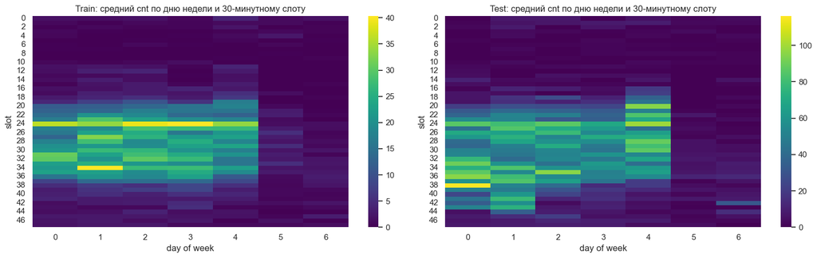

```python
fig, axes = plt.subplots(1, 2, figsize=(16, 5))

profile_train = train_marked.pivot_table(index="slot", columns="dow", values="cnt", aggfunc="mean")
profile_test = test_marked.pivot_table(index="slot", columns="dow", values="cnt", aggfunc="mean")

sns.heatmap(profile_train, ax=axes[0], cmap="viridis")
axes[0].set_title("Train: средний cnt по дню недели и 30-минутному слоту")
axes[0].set_xlabel("day of week")
axes[0].set_ylabel("slot")

sns.heatmap(profile_test, ax=axes[1], cmap="viridis")
axes[1].set_title("Test: средний cnt по дню недели и 30-минутному слоту")
axes[1].set_xlabel("day of week")
axes[1].set_ylabel("slot")

plt.tight_layout()
plt.show()
```

## Валидация внутри train

Для временных рядов нельзя перемешивать наблюдения. В качестве локальной проверки отделим последние 14 дней train как validation. Это имитирует будущий прогноз.

```python
train_supervised = ts_model.make_supervised_frame(counters_train, events_train)
valid_start = train_supervised["dt"].max() - pd.Timedelta(days=14)

fit_part = train_supervised[train_supervised["dt"] < valid_start].dropna().copy()
valid_part = train_supervised[train_supervised["dt"] >= valid_start].copy()

print("fit period  :", fit_part["dt"].min(), "-", fit_part["dt"].max(), fit_part.shape)
print("valid period:", valid_part["dt"].min(), "-", valid_part["dt"].max(), valid_part.shape)
```

```
fit period  : 2005-07-31 00:00:00 - 2005-09-21 23:00:00 (2543, 37)
valid period: 2005-09-21 23:30:00 - 2005-10-05 23:30:00 (673, 37)
```

```python
def seasonal_slot_mean_forecast(train_df, future_df):
    slot_mean = train_df.groupby(["dow", "slot"])["cnt"].mean()
    global_mean = train_df["cnt"].mean()
    preds = []
    for _, row in future_df.iterrows():
        preds.append(slot_mean.get((row["dow"], row["slot"]), global_mean))
    return np.asarray(preds, dtype=float)


def last_week_recursive_forecast(train_df, future_df, fallback_pred):
    history = train_df.set_index("dt")["cnt"].copy()
    preds = []
    for i, row in future_df.iterrows():
        lag_dt = row["dt"] - pd.Timedelta(minutes=30 * 336)
        pred = history.get(lag_dt, fallback_pred[len(preds)])
        pred = max(0.0, float(pred))
        preds.append(pred)
        history.loc[row["dt"]] = pred
    return np.asarray(preds, dtype=float)


valid_seasonal_mean = seasonal_slot_mean_forecast(fit_part, valid_part)
valid_last_week = last_week_recursive_forecast(fit_part, valid_part, valid_seasonal_mean)

valid_results = {
    "seasonal_slot_mean": regression_metrics(valid_part["cnt"], valid_seasonal_mean),
    "last_week_recursive": regression_metrics(valid_part["cnt"], valid_last_week),
}

tmp_model = MallTrafficTimeSeries()
tmp_model.fit_time_origin(counters_train)
tmp_model.fit_regressor(counters_train[counters_train["dt"] < valid_start], events_train[events_train["dt_start"] < valid_start])
valid_future_counters = counters_train[counters_train["dt"] >= valid_start].copy()
valid_future_events = events_train[(events_train["dt_end"] >= valid_start)].copy()
valid_ml = tmp_model.predict_counts_recursive(valid_future_counters, valid_future_events)
valid_results["hgb_poisson_event_lags"] = regression_metrics(valid_future_counters["cnt"], valid_ml["cnt_pred"])

valid_results_df = pd.DataFrame(valid_results).T.sort_values("MAE")
display(valid_results_df)
```

|  | MAE | RMSE | SMAPE_% | Bias | R2 |
| --- | --- | --- | --- | --- | --- |
| hgb_poisson_event_lags | 7.3362 | 15.8460 | 129.2095 | 4.4568 | 0.5160 |
| last_week_recursive | 8.3358 | 17.0428 | 73.3188 | 3.5334 | 0.4401 |
| seasonal_slot_mean | 9.2884 | 19.1946 | 109.6972 | 8.3542 | 0.2898 |

## Финальное обучение и прогноз на test

Финальная модель обучается на всем train. В test она использует расписание будущих мероприятий, календарь и рекурсивные лаги. Настоящие `cnt` из test используются только для расчета метрик после прогноза.

```python
final_model = MallTrafficTimeSeries()
final_model.fit_time_origin(counters_train)
final_model.fit_regressor(counters_train, events_train)

test_prediction_frame = final_model.predict_counts_recursive(counters_test, events_test)
test_pred_ml = test_prediction_frame["cnt_pred"].to_numpy()

test_base = final_model.preprocess(counters_test, events_test)
test_train_base = final_model.preprocess(counters_train, events_train)

test_seasonal_mean = seasonal_slot_mean_forecast(test_train_base, test_base)
test_last_week = last_week_recursive_forecast(test_train_base, test_base, test_seasonal_mean)

try:
    ets_model = ExponentialSmoothing(
        counters_train.set_index("dt")["cnt"].asfreq("30min"),
        trend="add",
        seasonal="add",
        seasonal_periods=48,
        initialization_method="estimated",
    ).fit(optimized=True)
    test_ets = np.clip(ets_model.forecast(len(counters_test)).to_numpy(), 0, None)
except Exception as exc:
    print("ETS failed:", repr(exc))
    test_ets = np.full(len(counters_test), counters_train["cnt"].mean())

test_results = {
    "seasonal_slot_mean": regression_metrics(counters_test["cnt"], test_seasonal_mean),
    "last_week_recursive": regression_metrics(counters_test["cnt"], test_last_week),
    "holt_winters_daily": regression_metrics(counters_test["cnt"], test_ets),
    "hgb_poisson_event_lags": regression_metrics(counters_test["cnt"], test_pred_ml),
}

test_results_df = pd.DataFrame(test_results).T.sort_values("MAE")
display(test_results_df)
```

|  | MAE | RMSE | SMAPE_% | Bias | R2 |
| --- | --- | --- | --- | --- | --- |
| hgb_poisson_event_lags | 11.2529 | 25.2814 | 120.8708 | 5.5873 | 0.4316 |
| last_week_recursive | 13.3313 | 28.5979 | 81.8712 | 5.0746 | 0.2727 |
| seasonal_slot_mean | 15.0393 | 31.2233 | 121.9281 | 14.0957 | 0.1330 |
| holt_winters_daily | 17.5973 | 32.4637 | 133.3205 | 11.0553 | 0.0627 |

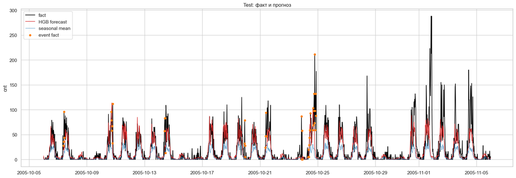

```python
plot_df = counters_test.copy()
plot_df["seasonal_slot_mean"] = test_seasonal_mean
plot_df["last_week_recursive"] = test_last_week
plot_df["holt_winters_daily"] = test_ets
plot_df["hgb_poisson_event_lags"] = test_pred_ml
plot_df["is_event"] = test_base["is_event"].to_numpy()

fig, ax = plt.subplots(figsize=(17, 6))
ax.plot(plot_df["dt"], plot_df["cnt"], color="black", lw=1.3, label="fact")
ax.plot(plot_df["dt"], plot_df["hgb_poisson_event_lags"], color="#d62728", lw=1.1, label="HGB forecast")
ax.plot(plot_df["dt"], plot_df["seasonal_slot_mean"], color="#1f77b4", alpha=0.7, lw=0.9, label="seasonal mean")
event_points = plot_df[plot_df["is_event"] == 1]
ax.scatter(event_points["dt"], event_points["cnt"], color="#ff7f0e", s=18, label="event fact", zorder=3)
ax.set_title("Test: факт и прогноз")
ax.set_ylabel("cnt")
ax.legend(loc="upper left")
plt.tight_layout()
plt.show()
```

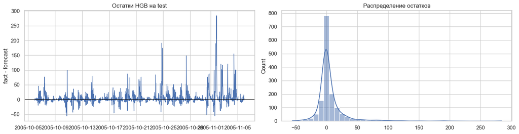

| is_event | abs_error mean | abs_error median | abs_error max | error mean | error median | error max |
| --- | --- | --- | --- | --- | --- | --- |
| 0 | 10.4427 | 3.7881 | 284.3233 | 4.9230 | -0.2825 | 284.3233 |
| 1 | 36.6518 | 18.8830 | 191.5310 | 26.4126 | 16.8201 | 191.5310 |

```python
residuals = counters_test["cnt"].to_numpy() - test_pred_ml

fig, axes = plt.subplots(1, 2, figsize=(15, 4))
axes[0].plot(counters_test["dt"], residuals, lw=1)
axes[0].axhline(0, color="black", lw=1)
axes[0].set_title("Остатки HGB на test")
axes[0].set_ylabel("fact - forecast")

sns.histplot(residuals, bins=40, kde=True, ax=axes[1])
axes[1].set_title("Распределение остатков")

plt.tight_layout()
plt.show()

error_by_event = pd.DataFrame({
    "abs_error": np.abs(residuals),
    "error": residuals,
    "is_event": test_base["is_event"].to_numpy(),
}).groupby("is_event").agg(["mean", "median", "max"])
display(error_by_event)
```

## Классификация события

Отдельно решим задачу классификации `is_event`. Для честности классификатор **не получает расписание событий** (`is_event`, длительность, прогресс события и т.п. исключены из признаков) и не получает будущие значения. Он использует календарные признаки и лаги счетчика.

Такой таргет сильно несбалансирован, поэтому кроме accuracy нужны ROC-AUC и PR-AUC, а также precision/recall/F1 при выбранном пороге.

```python
class_model = MallTrafficTimeSeries()
class_model.fit_time_origin(counters_train)
class_model.fit_event_classifier(counters_train, events_train)

test_event_prob = class_model.predict_event_probability(counters_test, events_test)

threshold_table = []
for threshold in [0.2, 0.3, 0.4, 0.5]:
    threshold_table.append(classification_metrics(test_base["is_event"], test_event_prob, threshold=threshold))

classification_results_df = pd.DataFrame(threshold_table)
display(classification_results_df)

best_threshold = classification_results_df.sort_values("f1", ascending=False).iloc[0]["threshold"]
best_classification_metrics = classification_metrics(test_base["is_event"], test_event_prob, threshold=float(best_threshold))
display(pd.DataFrame([best_classification_metrics], index=["best_by_f1"]))
```

|  | threshold | accuracy | precision | recall | f1 | roc_auc | pr_auc |
| --- | --- | --- | --- | --- | --- | --- | --- |
| 0 | 0.2000 | 0.7480 | 0.0793 | 0.6739 | 0.1419 | 0.8093 | 0.0918 |
| 1 | 0.3000 | 0.8226 | 0.0871 | 0.5000 | 0.1484 | 0.8093 | 0.0918 |
| 2 | 0.4000 | 0.8790 | 0.1012 | 0.3696 | 0.1589 | 0.8093 | 0.0918 |
| 3 | 0.5000 | 0.9241 | 0.0759 | 0.1304 | 0.0960 | 0.8093 | 0.0918 |

|  | threshold | accuracy | precision | recall | f1 | roc_auc | pr_auc |
| --- | --- | --- | --- | --- | --- | --- | --- |
| best_by_f1 | 0.4000 | 0.8790 | 0.1012 | 0.3696 | 0.1589 | 0.8093 | 0.0918 |

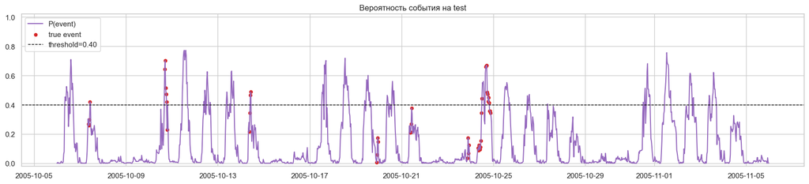

```python
clf_plot = pd.DataFrame({
    "dt": counters_test["dt"],
    "is_event": test_base["is_event"].to_numpy(),
    "event_probability": test_event_prob,
})

fig, ax = plt.subplots(figsize=(17, 4))
ax.plot(clf_plot["dt"], clf_plot["event_probability"], label="P(event)", color="#9467bd")
ax.scatter(
    clf_plot.loc[clf_plot["is_event"] == 1, "dt"],
    clf_plot.loc[clf_plot["is_event"] == 1, "event_probability"],
    color="#d62728",
    s=20,
    label="true event",
)
ax.axhline(float(best_threshold), color="black", ls="--", lw=1, label=f"threshold={best_threshold:.2f}")
ax.set_title("Вероятность события на test")
ax.set_ylim(-0.02, 1.02)
ax.legend(loc="upper left")
plt.tight_layout()
plt.show()
```

## Сохранение результатов

```python
submission_like = counters_test.copy()
submission_like["is_event"] = test_base["is_event"].to_numpy()
submission_like["cnt_pred"] = test_pred_ml
submission_like["event_probability"] = test_event_prob
submission_like["event_pred"] = (test_event_prob >= float(best_threshold)).astype(int)

submission_like.to_csv("ml6_test_predictions.csv", index=False)
display(submission_like.head(10))
print("Saved:", Path("ml6_test_predictions.csv").resolve())
```

|  | dt | cnt | is_event | cnt_pred | event_probability | event_pred |
| --- | --- | --- | --- | --- | --- | --- |
| 0 | 2005-10-06 00:00:00 | 4 | 0 | 7.1319 | 0.0003 | 0 |
| 1 | 2005-10-06 00:30:00 | 4 | 0 | 0.7431 | 0.0026 | 0 |
| 2 | 2005-10-06 01:00:00 | 0 | 0 | 1.2334 | 0.0057 | 0 |
| 3 | 2005-10-06 01:30:00 | 0 | 0 | 0.4180 | 0.0003 | 0 |
| 4 | 2005-10-06 02:00:00 | 0 | 0 | 0.7868 | 0.0003 | 0 |
| 5 | 2005-10-06 02:30:00 | 0 | 0 | 0.3922 | 0.0003 | 0 |
| 6 | 2005-10-06 03:00:00 | 0 | 0 | 0.7710 | 0.0003 | 0 |
| 7 | 2005-10-06 03:30:00 | 4 | 0 | 0.1166 | 0.0003 | 0 |
| 8 | 2005-10-06 04:00:00 | 4 | 0 | 0.1470 | 0.0075 | 0 |
| 9 | 2005-10-06 04:30:00 | 0 | 0 | 0.1542 | 0.0138 | 0 |

```
Saved: C:\Users\user\Desktop\Институт\2 курс\МТС ШАД\Домашние задания\ML 6\ml6_test_predictions.csv
```

## Выводы по метрикам

MAE и RMSE измеряются в посетителях и хорошо интерпретируются для счетчика. RMSE сильнее штрафует крупные ошибки, поэтому полезен при пиках. SMAPE выбран вместо MAPE, потому что в ряду много нулевых значений и обычный MAPE становится нестабильным. Bias показывает систематическое завышение или занижение прогноза, R2 показывает долю объясненной вариации относительно константной модели.

Для классификации accuracy не является главной метрикой: событие редкое, и модель, почти всегда отвечающая "нет события", уже получила бы высокую accuracy. Поэтому дополнительно используются recall, precision, F1, ROC-AUC и особенно PR-AUC, чувствительная к качеству на редком положительном классе.

## Итоговые выводы после запуска ноутбука

После полного выполнения ноутбука получились такие ключевые результаты:

- Лучшая регрессионная модель по MAE: **hgb_poisson_event_lags**.
- На test она получила **MAE = 11.25**, **RMSE = 25.28**, **SMAPE = 120.87%**, **R2 = 0.432**, **Bias = 5.59**.
- Сезонное среднее по дню недели и 30-минутному слоту дало **MAE = 15.04** и **R2 = 0.133**, поэтому учет лагов, тренда и мероприятий действительно улучшил прогноз.
- В test размечено **46** event-точек из **1488** (**3.09%**), то есть это редкий положительный класс.
- Лучший порог классификатора по F1: **0.40**. При нем **precision = 0.101**, **recall = 0.370**, **F1 = 0.159**, **ROC-AUC = 0.809**, **PR-AUC = 0.092**.
- Качество классификации ограничено дисбалансом и тем, что событие не всегда однозначно восстанавливается только по календарю и прошлому потоку. Для прогноза посетителей расписание мероприятий используется напрямую, что разрешено условием и дает более полезный бизнес-прогноз.

```python
best_model_name = test_results_df.index[0]
best_reg = test_results_df.loc[best_model_name]
base_reg = test_results_df.loc["seasonal_slot_mean"]
best_cls = pd.Series(best_classification_metrics)
event_rows = int(test_base["is_event"].sum())
event_share = test_base["is_event"].mean() * 100

display(Markdown(f'''
### Итоговые выводы после запуска

- Лучшая регрессионная модель по MAE: **{best_model_name}**.
- На test она получила MAE = **{best_reg["MAE"]:.2f}**, RMSE = **{best_reg["RMSE"]:.2f}**, SMAPE = **{best_reg["SMAPE_%"]:.2f}%**, R2 = **{best_reg["R2"]:.3f}**, Bias = **{best_reg["Bias"]:.2f}**.
- Сезонное среднее по дню недели и 30-минутному слоту дало MAE = **{base_reg["MAE"]:.2f}** и R2 = **{base_reg["R2"]:.3f}**, поэтому учет лагов, тренда и мероприятий действительно улучшил прогноз.
- В test размечено **{event_rows}** event-точек из **{len(test_base)}** ({event_share:.2f}%). Это редкий класс.
- Лучший порог классификатора по F1: **{best_cls["threshold"]:.2f}**. При нем precision = **{best_cls["precision"]:.3f}**, recall = **{best_cls["recall"]:.3f}**, F1 = **{best_cls["f1"]:.3f}**, ROC-AUC = **{best_cls["roc_auc"]:.3f}**, PR-AUC = **{best_cls["pr_auc"]:.3f}**.
- Качество классификации ограничено дисбалансом и тем, что событие не всегда однозначно восстанавливается только по календарю и прошлому потоку. Для прогноза посетителей расписание мероприятий используется напрямую, что разрешено условием и дает более полезный бизнес-прогноз.
'''))
```

Итоговые выводы после запуска

- Лучшая регрессионная модель по MAE: **hgb_poisson_event_lags**.

- На test она получила MAE = **11.25**, RMSE = **25.28**, SMAPE = **120.87%**, R2 = **0.432**, Bias = **5.59**.

- Сезонное среднее по дню недели и 30-минутному слоту дало MAE = **15.04** и R2 = **0.133**, поэтому учет лагов, тренда и мероприятий действительно улучшил прогноз.

- В test размечено **46** event-точек из **1488** (3.09%). Это редкий класс.

- Лучший порог классификатора по F1: **0.40**. При нем precision = **0.101**, recall = **0.370**, F1 = **0.159**, ROC-AUC = **0.809**, PR-AUC = **0.092**.

- Качество классификации ограничено дисбалансом и тем, что событие не всегда однозначно восстанавливается только по календарю и прошлому потоку. Для прогноза посетителей расписание мероприятий используется напрямую, что разрешено условием и дает более полезный бизнес-прогноз.